# Spatial Sampling Bias

Prof. Harbert

Lab 7A

# Bias in Occurrence Data

Most modeling assumes random samples of data. In Biodiversity informatics that is rarely the case. Humans tend to go where it is easy for us to get and/or where we are going to go anyways. For that reason spatial occurrence data tends to be clustered towards the more commonly visited places.

Today we will explore visualization tools for examining patterns in occurrence data samples.

# rasterExtras & RSpatial

[rasterExtras GitHub](https://github.com/rsh249/rasterExtras) [rasterExtras Tutorials](https://rsh249.github.io/demo/rasterExtras.html)

[RSpatial GitHub](https://github.com/oshea-patrick/RSpatial)

Install the R package rasterExtras using

```r
devtools::install_github('rsh249/rasterExtras')
devtools::install_github('oshea-patrick/RSpatial')
```

## Sampling Density

Start with the species that you downloaded data on for homework and load the WorldClim data again.

```r
library(raster)
```

```r
library(ggplot2)
library(rasterExtras)
library(RSpatial)
library(spocc)
library(dplyr)
wc = getData('worldclim', var='bio', res = 5)
ext = extent(-125, -55, 20, 60)
wc = crop(wc, ext)

wc_df = as.data.frame(wc, xy=TRUE)

taxon = 'Vaccinium angustifolium'

spdist <- occ(query=taxon, limit=6500)
sp_df = occ2df(spdist)

sp_df = sp_df %>% filter(longitude>=ext[1], longitude<=ext[2], latitude>=ext[3], latitude <=ext[4]) #dplyr filter points to study area

gk = gkde(wc[[1]],
          sp_df[,c('longitude', 'latitude')],
          parallel=T,
          nclus = 12,
          dist.method='Haversine',
          maxram=20,
          bw=50)
```

```
## BEGIN PARALLEL COMPUTATION
## Core count:  12
## Cells/iteration:  5513 of 403200
## Iterations total:  73.13622
## Points:  3381
## Maximum RAM per proc.:  1.666667
## Distance Method:  Haversine
##
## Time elapsed:  33.757
```

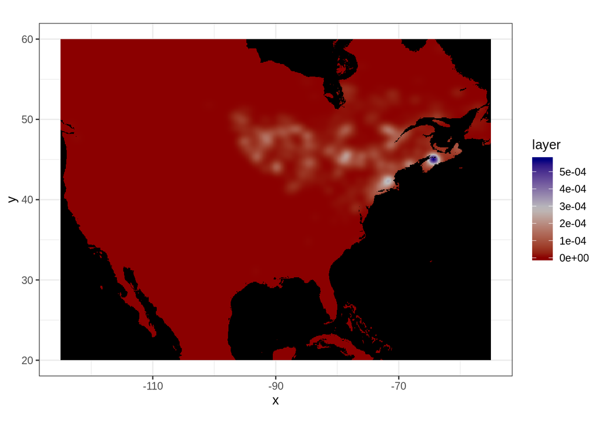

```r
gk_df=as.data.frame(gk, xy=TRUE)
ggplot() +
  geom_raster(data = gk_df, aes(x = x, y = y, fill = layer)) +
  #geom_point(data=sp_df, aes(x=longitude, y=latitude), col='green', cex=0.1) +
  coord_quickmap() +
  theme_bw() +
  scale_fill_gradientn(colours=c('darkred', 'grey', 'navy'),
  na.value = "black")
```

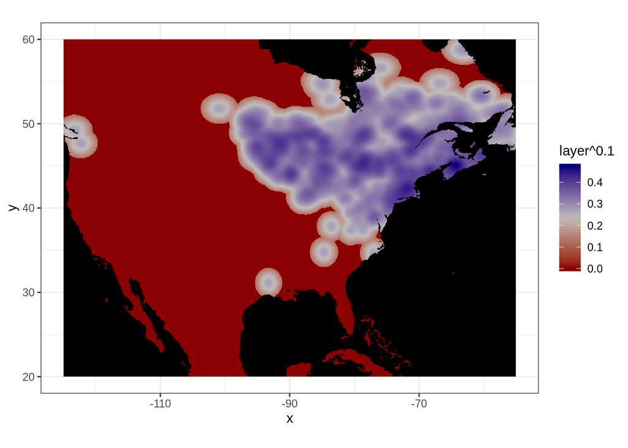

```r
ggplot() +
  geom_raster(data = gk_df, aes(x = x, y = y, fill = layer^0.1)) +
  coord_quickmap() +
  theme_bw() +
  scale_fill_gradientn(colours=c('darkred', 'grey', 'navy'),
  na.value = "black")
```

### SAVE YOUR MAP

I like the last density map (the 10th root one). To save any plot in R:

```r
dplot = ggplot() +
  geom_raster(data = gk_df, aes(x = x, y = y, fill = layer^0.1)) +
  coord_quickmap() +
  theme_bw() +
  scale_fill_gradientn(colours=c('darkred', 'grey', 'navy'),
  na.value = "black")

ggsave(dplot, filename = paste("figure/", taxon, "_density.png", sep=""))
#or
ggsave(dplot, filename = "figure/Vaccinium_density.png")
#and you can change the size and resolution (dpi) if you want a higher quality figure.
ggsave(dplot,
       filename = paste("figure/", taxon, "_density.png", sep=""),
       height=7.25, width = 7.25, units='in',
       dpi = 300)
```

To save the *DATA* you generated as a raster file (which could be reused in R later):

```r
writeRaster(gk, filename = paste('data/', taxon, '_density', sep=''), overwrite=TRUE)
```

```
## class      : RasterLayer
## dimensions : 480, 840, 403200  (nrow, ncol, ncell)
## resolution : 0.08333333, 0.08333333  (x, y)
## extent     : -125, -55, 20, 60  (xmin, xmax, ymin, ymax)
## crs        : +proj=longlat +datum=WGS84 +ellps=WGS84 +towgs84=0,0,0
## source     : /home/rharbert/GitHub/bioinformatics/docs/data/Vaccinium angustifolium_density.grd
## names      : layer
## values     : 0, 0.000569195  (min, max)
```

## Minimum Distance

Alternate visualization: The minimum distance to the nearest occurrence point. Identifies undersampled areas by mapping the distance to a point in the dataset.

```r
d2pt = dist2point(wc[[1]], sp_df[,c('longitude', 'latitude')], parallel=TRUE, nclus = 12, dist.method='Haversine', maxram = 20)
```

```
## BEGIN PARALLEL COMPUTATION
## Core count:  12
## Cells/iteration:  5513 of 403200
## Iterations total:  73.13622
## Points:  3381
## Maximum RAM per proc.:  1.666667
## Distance Method:  Haversine
##
## Time elapsed:  19.96
```

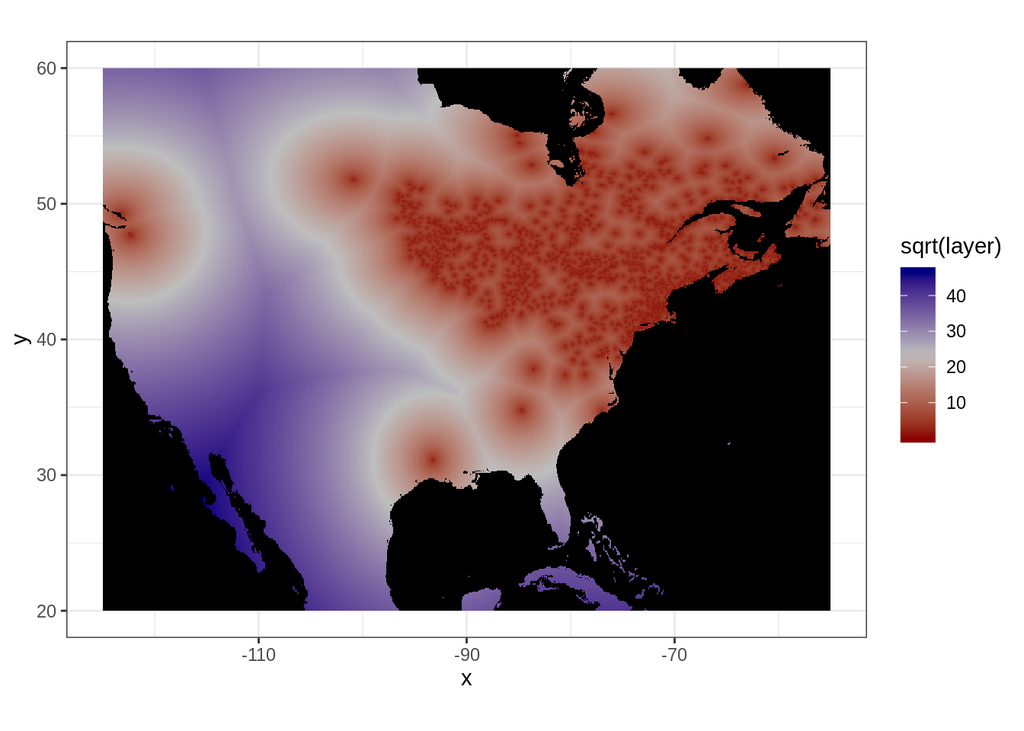

```r
d2_df = as.data.frame(d2pt, xy=T)

ggplot() +
  geom_raster(data = d2_df, aes(x = x, y = y, fill = sqrt(layer))) +
  #geom_point(data=sp_df, aes(x=longitude, y=latitude), col='green', cex=0.2) +
  coord_quickmap() +
  theme_bw() +
  scale_fill_gradientn(colours=c('darkred', 'grey', 'navy'),
  na.value = "black")
```

### Save it

```r
distplot = ggplot() +
  geom_raster(data = d2_df, aes(x = x, y = y, fill = sqrt(layer))) +
  #geom_point(data=sp_df, aes(x=longitude, y=latitude), col='green', cex=0.2) +
  coord_quickmap() +
  theme_bw() +
  scale_fill_gradientn(colours=c('darkred', 'grey', 'navy'),
  na.value = "black")

ggsave(distplot,
       filename = paste("figure/", taxon, "_mindist.png", sep=""),
       height=7.25, width = 7.25, units='in',
       dpi = 300)

writeRaster(gk, filename = paste('data/', taxon, '_mindist', sep=''), overwrite=TRUE )
```

```
## class      : RasterLayer
## dimensions : 480, 840, 403200  (nrow, ncol, ncell)
## resolution : 0.08333333, 0.08333333  (x, y)
## extent     : -125, -55, 20, 60  (xmin, xmax, ymin, ymax)
## crs        : +proj=longlat +datum=WGS84 +ellps=WGS84 +towgs84=0,0,0
## source     : /home/rharbert/GitHub/bioinformatics/docs/data/Vaccinium angustifolium_mindist.grd
## names      : layer
## values     : 0, 0.000569195  (min, max)
```

# Fixing bias: Spatial Thinning

One way to reduce bias in your sample is to *thin* the data. That is, by removing points from the dataset that fall too close together we can smooth out the sampling.

```r
#from RSpatial
library(RSpatial)
occ2thin = poThin(
  df = sp_df[c('longitude', 'latitude')],
  spacing = 25,
  dimension = nrow(sp_df),
  lon = 'longitude',
  lat = 'latitude'
)

sp_df = sp_df[-occ2thin,]

gk = gkde(wc[[1]],
          sp_df[,c('longitude', 'latitude')],
          parallel=T,
          nclus = 12,
          dist.method='Haversine',
          maxram=20,
          bw=50)
```

```
## BEGIN PARALLEL COMPUTATION
## Core count:  12
## Cells/iteration:  27657 of 403200
## Iterations total:  14.57859
## Points:  674
## Maximum RAM per proc.:  1.666667
## Distance Method:  Haversine
##
## Time elapsed:  26.8
```

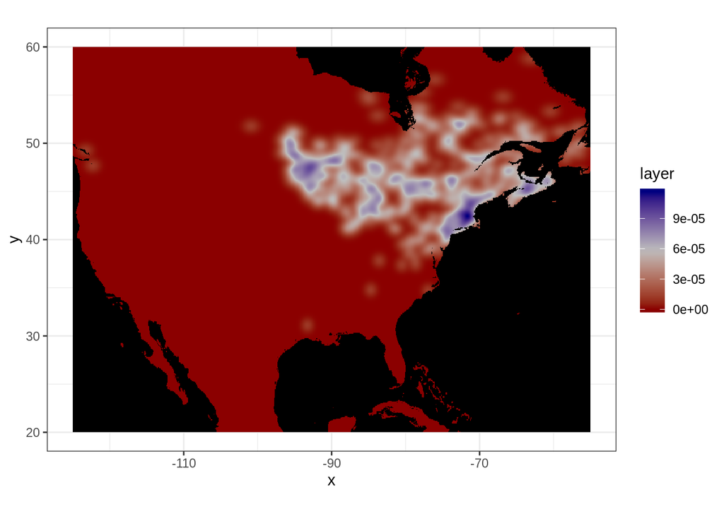

```r
gk_df=as.data.frame(gk, xy=TRUE)
ggplot() +
  geom_raster(data = gk_df, aes(x = x, y = y, fill = layer)) +
  #geom_point(data=sp_df, aes(x=longitude, y=latitude), col='green', cex=0.1) +
  coord_quickmap() +
  theme_bw() +
  scale_fill_gradientn(colours=c('darkred', 'grey', 'navy'),
  na.value = "black")
```

# Homework

Change the extent of your study area to focus on New England and generate density and distance to point maps for your species.

In your dataset whata areas look undersampled? What patterns in the distribution do not look *biological*?

HINT:

```r
ext = extent(-74, -69, 40, 45)
#crop

#Or filter points to study area and run gkde() and dist2point() again
```

[home](https://rsh249.github.io/bioinformatics)